# Chapter 5: Resampling Methods

Paulo Loyola

Carrega o pacote utilizado:

```r
library(ISLR)
```

**2)** **g)**

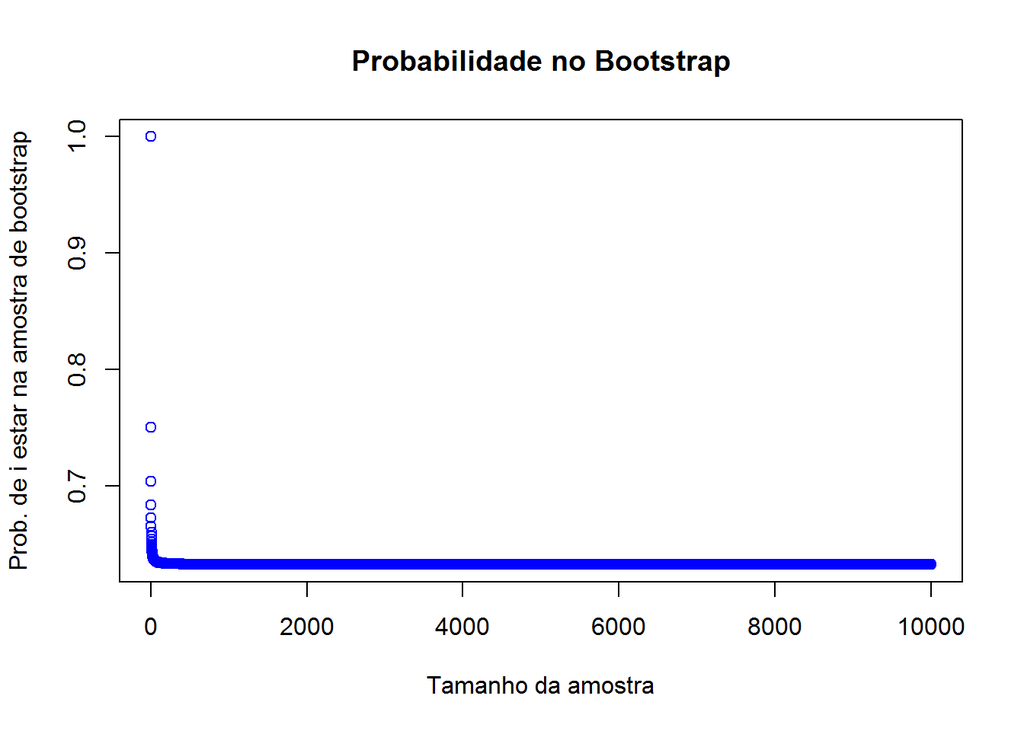

```r
x = seq(1, 10000)
y = c()
for (i in 1:10000) {
  y[i] = 1 - ((i - 1)/i)^i
}
plot(y ~ x, ylab = "Prob. de i estar na amostra de bootstrap", xlab = "Tamanho da amostra", col = "blue", main = "Probabilidade no Bootstrap")
```

```r
min(y)
```

```
## [1] 0.632139
```

```r
median(y)
```

```
## [1] 0.6321573
```

```r
mean(y)
```

```
## [1] 0.632325
```

O gráfico e o valor mínimo, mediano e médio obtido anteriormente mostram que a conforme N aumenta a tendência é que a probabilidade de que a i-ésima observação esteja na amostra de bootstrap é de aproximadamente 63,2%.

**5)**

**a)**

```r
summary(glm(default ~ income + balance, data = Default, family = "binomial"))
```

```
##
## Call:
## glm(formula = default ~ income + balance, family = "binomial",
##     data = Default)
##
## Deviance Residuals:
##     Min       1Q   Median       3Q      Max
## -2.4725  -0.1444  -0.0574  -0.0211   3.7245
##
## Coefficients:
##               Estimate Std. Error z value Pr(>|z|)
## (Intercept) -1.154e+01  4.348e-01 -26.545  < 2e-16 ***
## income       2.081e-05  4.985e-06   4.174 2.99e-05 ***
## balance      5.647e-03  2.274e-04  24.836  < 2e-16 ***
## ---
## Signif. codes:  0 '***' 0.001 '**' 0.01 '*' 0.05 '.' 0.1 ' ' 1
##
## (Dispersion parameter for binomial family taken to be 1)
##
##     Null deviance: 2920.6  on 9999  degrees of freedom
## Residual deviance: 1579.0  on 9997  degrees of freedom
## AIC: 1585
##
## Number of Fisher Scoring iterations: 8
```

**b)** Validation Approach: divide o banco Default em train e test e procede com a análise do modelo obtido em train para prever o banco test:

```r
set.seed(1)
train = sample(nrow(Default), nrow(Default)/2)
Modelo1 = glm(default ~ income + balance, data = Default, subset = train, family = "binomial")
Modelo1.probs = predict(Modelo1, Default[-train,], type = "response")
Modelo1.pred = ifelse(Modelo1.probs > .5, "Yes", "No")
table(Modelo1.pred, Default[-train,"default"])
```

```
##
## Modelo1.pred   No  Yes
##          No  4805  115
##          Yes   28   52
```

```r
1 - mean(Modelo1.pred == Default[-train,"default"])
```

```
## [1] 0.0286
```

Com a abordagem do Validation Set obtemos um test error rate de 2,86%. Apesar de parecer, o modelo não é muito bom, pois o erro que se espera caso chute-se sempre em “No” é de 3,33%.

**c)** Faz função que retorna o test error rate da Validation Set Approach no Banco Default de acordo com o seed dado:

```r
ValidationSet = function(seed) {
  set.seed(seed)
  train = sample(nrow(Default), nrow(Default)/2)
  Modelo = glm(default ~ income + balance, data = Default, subset = train, family = "binomial")
  Modelo.probs = predict(Modelo, Default[-train,], type = "response")
  Modelo.pred = ifelse(Modelo.probs > .5, "Yes", "No")
  print(table(Modelo.pred, Default[-train,"default"]))
  return(1 - mean(Modelo.pred == Default[-train,"default"]))
}
```

Obtém o test error rate para seed 2, 3 e 4:

```r
mean(c(ValidationSet(2), ValidationSet(3), ValidationSet(4)))
```

```
##
## Modelo.pred   No  Yes
##         No  4811  118
##         Yes   20   51
##
## Modelo.pred   No  Yes
##         No  4828  108
##         Yes   16   48
##
## Modelo.pred   No  Yes
##         No  4813  112
##         Yes   19   56
```

```
## [1] 0.0262
```

A média dos test error rates ficam em 2,6%. As mesmas observações feitas no item b) cabem aqui.

**d)**

```r
set.seed(1)
train = sample(nrow(Default), nrow(Default)/2)
Modelo1 = glm(default ~ income + balance + student, data = Default, subset = train, family = "binomial")
Modelo1.probs = predict(Modelo1, Default[-train,], type = "response")
Modelo1.pred = ifelse(Modelo1.probs > .5, "Yes", "No")
table(Modelo1.pred, Default[-train,"default"])
```

```
##
## Modelo1.pred   No  Yes
##          No  4803  114
##          Yes   30   53
```

```r
1 - mean(Modelo1.pred == Default[-train,"default"])
```

```
## [1] 0.0288
```

Como o test error rate do primeiro modelo era de 2,86%, pelo novo test error rate de 2,88% vemos que adicionar a variável student ao modelo não melhora sua capacidade preditiva.

**6)** **a)**

```r
summary(glm(default ~ income + balance, data = Default, family = "binomial"))
```

```
##
## Call:
## glm(formula = default ~ income + balance, family = "binomial",
##     data = Default)
##
## Deviance Residuals:
##     Min       1Q   Median       3Q      Max
## -2.4725  -0.1444  -0.0574  -0.0211   3.7245
##
## Coefficients:
##               Estimate Std. Error z value Pr(>|z|)
## (Intercept) -1.154e+01  4.348e-01 -26.545  < 2e-16 ***
## income       2.081e-05  4.985e-06   4.174 2.99e-05 ***
## balance      5.647e-03  2.274e-04  24.836  < 2e-16 ***
## ---
## Signif. codes:  0 '***' 0.001 '**' 0.01 '*' 0.05 '.' 0.1 ' ' 1
##
## (Dispersion parameter for binomial family taken to be 1)
##
##     Null deviance: 2920.6  on 9999  degrees of freedom
## Residual deviance: 1579.0  on 9997  degrees of freedom
## AIC: 1585
##
## Number of Fisher Scoring iterations: 8
```

**b)** Função boot.fn():

```r
boot.fn = function(data = Default, index) {
  return(coef(glm(default ~ income + balance, data = data, subset = index, family = "binomial")))
}
```

Testa a função boot.fn():

```r
boot.fn(index = sample(nrow(Default), nrow(Default)/2))
```

```
##   (Intercept)        income       balance
## -1.135819e+01  2.264489e-05  5.530410e-03
```

**c)** Uso da função boot.fn() para estimar os erros padrão dos coeficientes do modelo apresentado em a):

```r
library(boot)
boot(Default, boot.fn, 500)
```

```
##
## ORDINARY NONPARAMETRIC BOOTSTRAP
##
##
## Call:
## boot(data = Default, statistic = boot.fn, R = 500)
##
##
## Bootstrap Statistics :
##          original        bias     std. error
## t1* -1.154047e+01  1.314636e-02 4.254935e-01
## t2*  2.080898e-05  1.106984e-07 4.710479e-06
## t3*  5.647103e-03 -1.070549e-05 2.227966e-04
```

**d)** Os erros padrão obtidos são bem próximos daqueles observados sem o uso de técnicas de bootstrap.

**7)** **a)**

```r
summary(glm(Direction ~ Lag1 + Lag2, data = Weekly, family = "binomial"))
```

```
##
## Call:
## glm(formula = Direction ~ Lag1 + Lag2, family = "binomial", data = Weekly)
##
## Deviance Residuals:
##    Min      1Q  Median      3Q     Max
## -1.623  -1.261   1.001   1.083   1.506
##
## Coefficients:
##             Estimate Std. Error z value Pr(>|z|)
## (Intercept)  0.22122    0.06147   3.599 0.000319 ***
## Lag1        -0.03872    0.02622  -1.477 0.139672
## Lag2         0.06025    0.02655   2.270 0.023232 *
## ---
## Signif. codes:  0 '***' 0.001 '**' 0.01 '*' 0.05 '.' 0.1 ' ' 1
##
## (Dispersion parameter for binomial family taken to be 1)
##
##     Null deviance: 1496.2  on 1088  degrees of freedom
## Residual deviance: 1488.2  on 1086  degrees of freedom
## AIC: 1494.2
##
## Number of Fisher Scoring iterations: 4
```

**b)**

```r
Modelo2 = glm(Direction ~ Lag1 + Lag2, data = Weekly[-1,], family = "binomial")
summary(Modelo2)
```

```
##
## Call:
## glm(formula = Direction ~ Lag1 + Lag2, family = "binomial", data = Weekly[-1,
##     ])
##
## Deviance Residuals:
##     Min       1Q   Median       3Q      Max
## -1.6258  -1.2617   0.9999   1.0819   1.5071
##
## Coefficients:
##             Estimate Std. Error z value Pr(>|z|)
## (Intercept)  0.22324    0.06150   3.630 0.000283 ***
## Lag1        -0.03843    0.02622  -1.466 0.142683
## Lag2         0.06085    0.02656   2.291 0.021971 *
## ---
## Signif. codes:  0 '***' 0.001 '**' 0.01 '*' 0.05 '.' 0.1 ' ' 1
##
## (Dispersion parameter for binomial family taken to be 1)
##
##     Null deviance: 1494.6  on 1087  degrees of freedom
## Residual deviance: 1486.5  on 1085  degrees of freedom
## AIC: 1492.5
##
## Number of Fisher Scoring iterations: 4
```

**c)**

```r
Modelo2.probs = predict(Modelo2, Weekly[1,], type = "response")
Modelo2.pred = ifelse(Modelo2.probs > .5, "Up", "Down")
Modelo2.pred == Weekly[1,"Direction"]
```

```
## [1] FALSE
```

A observação não foi corretamente classificada.

**d)** Função que faz LOOCV:

```r
LOOCV = function(data = Weekly){
  result = c()
  for (i in 1:nrow(data)) {
    ModeloX = glm(Direction ~ Lag1 + Lag2, data = data[-i,], family = "binomial")
    ModeloX.probs = predict(ModeloX, data[i,], type = "response")
    ModeloX.pred = ifelse(ModeloX.probs > .5, "Up", "Down")
    result[i] = ifelse(ModeloX.pred != data[i,"Direction"], 1, 0)
  }
  return(result)
}
```

**e)**

```r
mean(LOOCV())
```

```
## [1] 0.4499541
```

A estimativa do erro de teste com LOOCV é de 45%. Ou seja, espera-se um erro em 45% das vezes quando este modelo for utilizado.

**8)** **a)**

```r
set.seed(1)
x = rnorm(100)
y = x - 2 * x^2 + rnorm(100)
```

Neste modelo temos n = 100, o número de observações, e p = 2.  
Este modelo tem a forma $Y = \beta_1 X_1 - \beta_2 X^2_2 + \epsilon$, sendo que $\epsilon$ ~ $N(0;1)$. Escrevendo o modelo com os valores nele inseridos temos: $Y = X - 2X^2 + \epsilon$.

**b)**

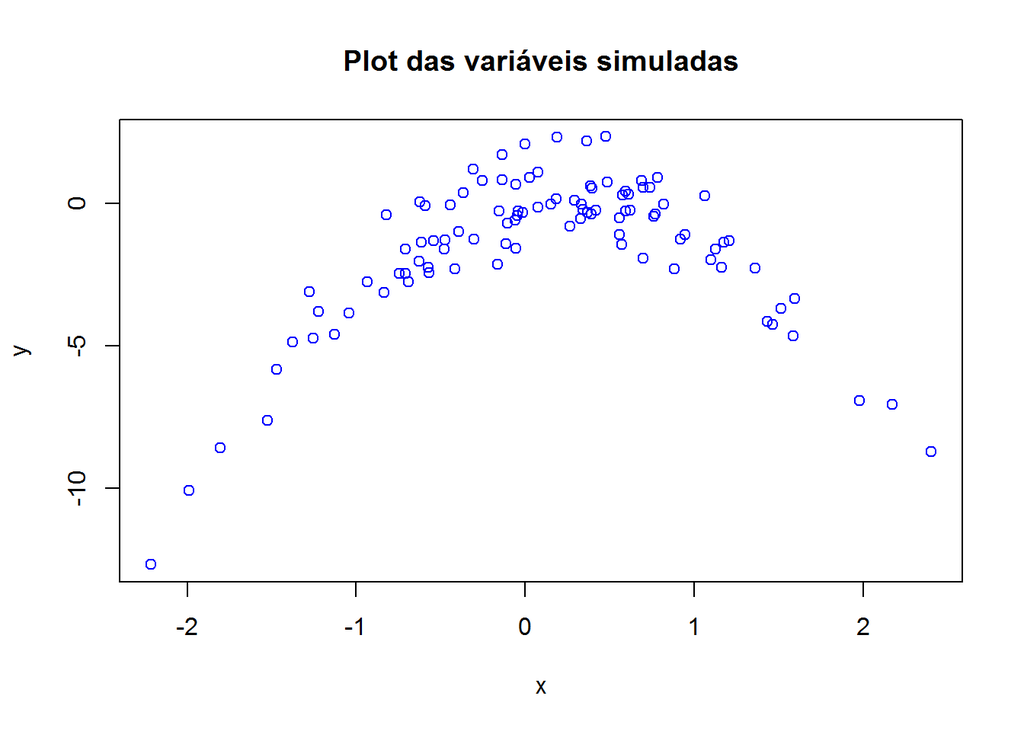

```r
plot(y ~ x, main = "Plot das variáveis simuladas", col = "blue")
```

Observa-se que X e Y têm uma relação não linear.

**c)**

```r
YX = data.frame(y, x)
```

LOOCV de $Y = \beta_0 + \beta_1 X + \epsilon$ até $Y = \beta_0 + \beta_1 X + \beta_2 X^2 + \beta_3 X^3 + \beta_4 X^4 + \epsilon$ com aumento de um grau no polinômio em cada modelo:

```r
set.seed(1)
cv.error = c()
for(i in 1:4){
  lm = glm(y ~ poly(x, i), data = YX)
  cv.error[i] = cv.glm(YX, lm)$delta[1]
}
cv.error
```

```
## [1] 7.2881616 0.9374236 0.9566218 0.9539049
```

Observa-se que há uma queda considerável na taxa de erro do banco teste quando mudamos para o modelo de grau 2, mas após isso não há nenhum ganho relevante em aumentar o grau do polinômio do modelo.

**d)**

```r
set.seed(2)
cv.error2 = c()
for(i in 1:4){
  lm = glm(y ~ poly(x, i), data = YX)
  cv.error2[i] = cv.glm(YX, lm)$delta[1]
}
cv.error2
```

```
## [1] 7.2881616 0.9374236 0.9566218 0.9539049
```

Os resultados obtidos são os mesmos. Isso se deve ao fato de que LOOCV não é afetado por nenhum fator aleatório, de modo que a seed não faz diferença nos estimadores encontrados.

**f)**

```r
summary(lm)
```

```
##
## Call:
## glm(formula = y ~ poly(x, i), data = YX)
##
## Deviance Residuals:
##     Min       1Q   Median       3Q      Max
## -2.0550  -0.6212  -0.1567   0.5952   2.2267
##
## Coefficients:
##              Estimate Std. Error t value Pr(>|t|)
## (Intercept)  -1.55002    0.09591 -16.162  < 2e-16 ***
## poly(x, i)1   6.18883    0.95905   6.453 4.59e-09 ***
## poly(x, i)2 -23.94830    0.95905 -24.971  < 2e-16 ***
## poly(x, i)3   0.26411    0.95905   0.275    0.784
## poly(x, i)4   1.25710    0.95905   1.311    0.193
## ---
## Signif. codes:  0 '***' 0.001 '**' 0.01 '*' 0.05 '.' 0.1 ' ' 1
##
## (Dispersion parameter for gaussian family taken to be 0.9197797)
##
##     Null deviance: 700.852  on 99  degrees of freedom
## Residual deviance:  87.379  on 95  degrees of freedom
## AIC: 282.3
##
## Number of Fisher Scoring iterations: 2
```

O p-valor dos coeficientes dos Modelos obtidos em *c)* corroboram com o esperado. Observa-se que os polinômios de grau 1 e grau 2 são estatisticamente significativos e aqueles de grau mais elevado não são. É o esperado uma vez que sabemos que Y é composta por um polinômio de grau 2.

**9)**

```r
library(MASS)
```

**a)** $\hat{\mu}$:

```r
mean(Boston$medv)
```

```
## [1] 22.53281
```

**b)** $SE(\hat{\mu})$:

```r
sd(Boston$medv)/sqrt(nrow(Boston))
```

```
## [1] 0.4088611
```

**c)**

```r
set.seed(1)
boot.fn = function(data = Boston, index){
  return(mean(data[index,"medv"]))
}
boot(Boston, boot.fn, 500)
```

```
##
## ORDINARY NONPARAMETRIC BOOTSTRAP
##
##
## Call:
## boot(data = Boston, statistic = boot.fn, R = 500)
##
##
## Bootstrap Statistics :
##     original     bias    std. error
## t1* 22.53281 -0.0117834   0.3967535
```

O erro padrão obtido por Bootstrap (0,4) é muito próximo do erro padrão obtido no item *b)* (0,41).

**d)**

```r
ci = c(mean(Boston$medv) - 2 * 0.3967535, mean(Boston$medv) + 2 * 0.3967535)
ci
```

```
## [1] 21.73930 23.32631
```

```r
t.test(Boston$medv)
```

```
##
##  One Sample t-test
##
## data:  Boston$medv
## t = 55.111, df = 505, p-value < 2.2e-16
## alternative hypothesis: true mean is not equal to 0
## 95 percent confidence interval:
##  21.72953 23.33608
## sample estimates:
## mean of x
##  22.53281
```

Novamente, os resultados obtidos são muito próximos.

**e)**

```r
median(Boston$medv)
```

```
## [1] 21.2
```

**f)**

```r
set.seed(1)
boot.fn = function(data = Boston, index){
  return(median(data[index, "medv"]))
}
boot(Boston, boot.fn, 500)
```

```
##
## ORDINARY NONPARAMETRIC BOOTSTRAP
##
##
## Call:
## boot(data = Boston, statistic = boot.fn, R = 500)
##
##
## Bootstrap Statistics :
##     original  bias    std. error
## t1*     21.2 -0.0312   0.3693635
```

O Erro Padrão da mediana foi estimado em 0,369.

**g)** $\hat{\mu}_{0.1}$:

```r
quantile(Boston$medv, 0.1)
```

```
##   10%
## 12.75
```

**h)** $\hat{\mu}_{0.1(Boot)}$:

```r
set.seed(1)
boot.fn = function(data = Boston, index) {
  return(quantile(data[index,"medv"], 0.1))
}
boot(Boston, boot.fn, 500)
```

```
##
## ORDINARY NONPARAMETRIC BOOTSTRAP
##
##
## Call:
## boot(data = Boston, statistic = boot.fn, R = 500)
##
##
## Bootstrap Statistics :
##     original  bias    std. error
## t1*    12.75  0.0159   0.5163288
```